# Survival_Analysis_week7

202430527 leetaenyoung

2025-10-19

# 1 Week 7 assignment

## 1.1 Question 1. Exercise 7

### 1.1.1 Data-Library import

```r
library(survival)
vets <- read.table("vets.txt", header = TRUE)
```

### 1.1.2 Pre-processing

```r
# 상태(status): 1=사망(사건발생), 0=검열
# 성능상태(PS): high(>=50) vs low(<50) 이분화
vets$PS_high <- as.integer(vets$PS >= 50)
vets$PS_grp  <- factor(vets$PS_high, levels = c(0,1),
                       labels = c("Low (<50)", "High (≥50)"))

# Surv 객체
Sobj <- with(vets, Surv(time, status == 1))
```

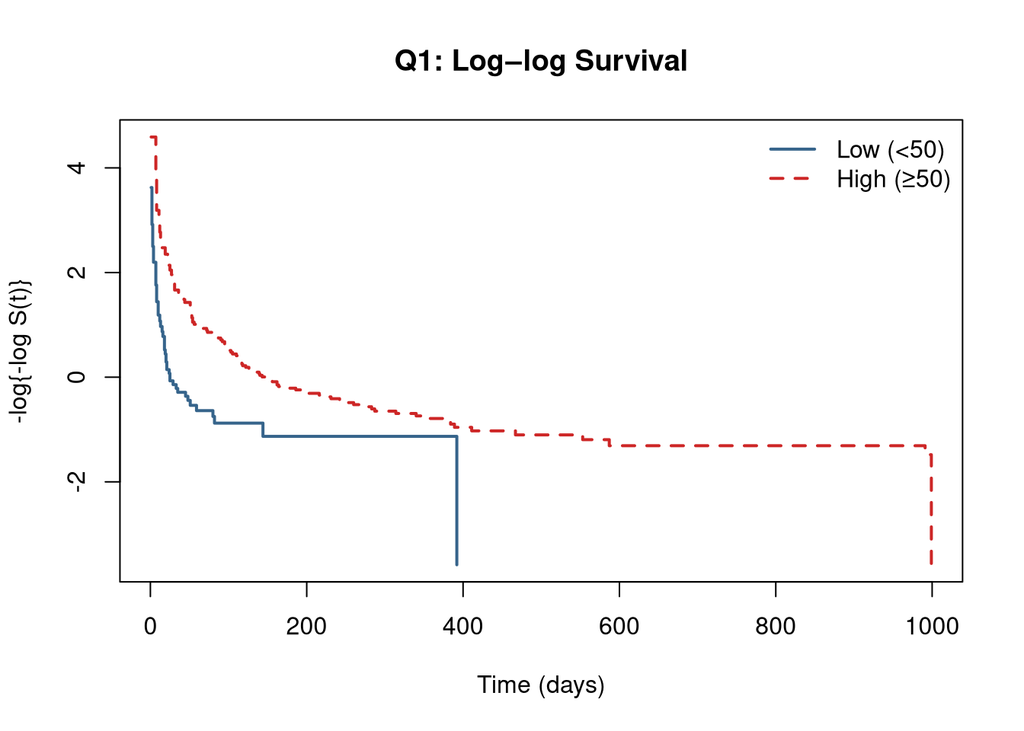

```r
# Kaplan–Meier 곡선
sf <- survfit(Sobj ~ PS_grp, data = vets)

# 데이터프레임 구성: x=시간, y=-log{-log S(t)}
to_ll <- function(fit, group_name) {
  eps <- .Machine$double.eps
  data.frame(
    group = group_name,
    time  = fit$time,
    surv  = fit$surv,
    x     = pmax(fit$time, 0),
    y     = -log(-log(pmax(fit$surv, eps)))
  )
}

get_group_df <- function(sf_obj) {
  out <- list(); off <- 0
  for (k in seq_along(sf_obj$strata)) {
    n   <- sf_obj$strata[k]
    idx <- seq_len(n) + off
    gnm <- names(sf_obj$strata)[k]
    out[[k]] <- to_ll(list(time = sf_obj$time[idx], surv = sf_obj$surv[idx]), gnm)
    off <- off + n
  }
  do.call(rbind, out)
}
df_ll <- get_group_df(sf)

# 그리기
op <- par(no.readonly = TRUE); on.exit(par(op))
plot(range(df_ll$x), range(df_ll$y), type = "n",
     xlab = "Time (days)", ylab = "-log{-log S(t)}",
     main = "Q1: Log–log Survival")

cols <- c("steelblue4", "firebrick3")
ltys <- c(1, 2)
grps <- levels(vets$PS_grp)
for (i in seq_along(grps)) {
  di <- subset(df_ll, group == paste0("PS_grp=", grps[i]))
  lines(di$x, di$y, type = "s", col = cols[i], lty = ltys[i], lwd = 2)
}
legend("topright", legend = grps, col = cols, lty = ltys, lwd = 2, bty = "n")
```

## 1.2 Question 1. Exercise 9

### 1.2.1 Pre-processing

```r
## 1) PS만 포함한 Cox PH 적합
fit_ps <- coxph(Sobj ~ PS_high, data = vets)
beta   <- unname(coef(fit_ps)["PS_high"])

## 2) 베이스라인 누적위험 및 생존함수
bh <- basehaz(fit_ps, centered = FALSE)     # columns: time, hazard = H0(t)
S0 <- exp(-bh$hazard)                        # baseline survival S0(t)

## 3) 군별 'Expected' 생존함수: S_exp(t|g) = S0(t)^{exp(beta*g)}
S_exp_low  <- S0^(exp(beta*0))
S_exp_high <- S0^(exp(beta*1))

## 4) 군별 'Observed' KM 생존함수
tmax  <- max(vets$time, na.rm = TRUE)
grid  <- seq(0, tmax, by = 5)  # 등간격 시간격자

sf <- survfit(Sobj ~ PS_high, data = vets)  # KM (두 군)
# grid 시점의 군별 KM 생존확률 뽑기
summ <- summary(sf, times = grid)
# summary는 두 군 결과가 섞여 오므로 분리
obs_low  <- data.frame(time = summ$time[summ$strata == "PS_high=0"],
                       surv = summ$surv [summ$strata == "PS_high=0"])
obs_high <- data.frame(time = summ$time[summ$strata == "PS_high=1"],
                       surv = summ$surv [summ$strata == "PS_high=1"])

## 5) Expected도 같은 grid
S0_grid <- approx(x = bh$time, y = S0, xout = grid, rule = 2, ties = mean)$y
exp_low  <- data.frame(time = grid, surv = S0_grid^(exp(beta*0)))
exp_high <- data.frame(time = grid, surv = S0_grid^(exp(beta*1)))
```

### 1.2.2 Observed vs Expected (O–E) 비교

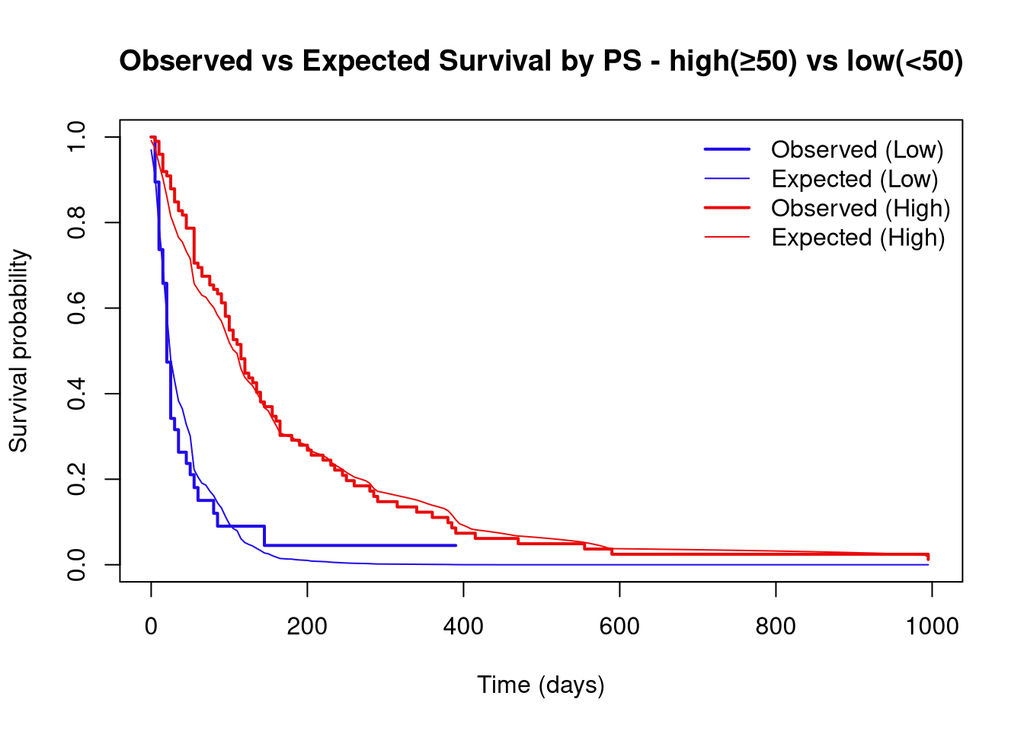

```r
# 그리기: 관측(실선) vs 기대(점선), 군별 색상/라인 구분
op <- par(no.readonly = TRUE); on.exit(par(op))
plot(c(0, tmax), c(0,1), type="n",
     xlab="Time (days)", ylab="Survival probability",
     main="Observed vs Expected Survival by PS - high(≥50) vs low(<50)")

# Observed: 굵은 실선(계단), Expected: 얇은 실선
# Low (<50)
lines(obs_low$time,  obs_low$surv,  type="s", lwd=2, col="#210be9")
lines(exp_low$time,  exp_low$surv,  type="l", lwd=1, col="#210be9")

# High (≥50)
lines(obs_high$time, obs_high$surv, type="s", lwd=2, col="#e90b0b")
lines(exp_high$time, exp_high$surv, type="l", lwd=1, col="#e90b0b")

legend("topright",
       legend = c("Observed (Low)","Expected (Low)","Observed (High)","Expected (High)"),
       lty = c(1,1,1,1), lwd = c(2,1,2,1),
       col = c("#210be9","#210be9","#e90b0b","#e90b0b"), bty="n")
```

### 1.2.3 Conclusion

- 각 군(High/Low)별 Observed 생존곡선이 Expected곡선과 전 구간에서 거의 겹치며, High–Low 두 군 사이의 상대적 간격도 시간이 지나도 크게 변하지 않습니다. 따라서 performance status에 대한 PH 가정은 대체로 타당하다고 결론 내릴 수 있습니다.

## 1.3 Question 2. Problem_Chap4

### 1.3.1 Data-Library import

```r
library(survival)
library(asaur) # For data loading
# 데이터 로드
data("hepatoCellular", package = "asaur")
hc <- hepatoCellular
```

### 1.3.2 Pre-processing

```r
to01 <- function(x) as.integer(as.numeric(x) != 0)

# Surv 객체 생성
hc$OS_time    <- hc$OS
hc$OS_status  <- to01(hc$Death)
hc$RFS_time   <- hc$RFS
hc$RFS_status <- to01(hc$Recurrence)

S_OS  <- with(hc,  Surv(OS_time,  OS_status))
S_RFS <- with(hc,  Surv(RFS_time, RFS_status))

cxcl_vars <- c("CXCL17T","CXCL17P","CXCL17N")
```

#### 1.3.2.1 (a) Cox compare : T/P/N

```r
safe_cox_one <- function(S, data, var){
  ok <- complete.cases(S[, "time"], S[, "status"], data[[var]])
  S2 <- S[ok]; d <- data[ok, , drop=FALSE]
  # 사건과 변동이 충분한지 확인
  if (sum(S2[, "status"]==1L)==0L || length(unique(d[[var]]))<2L)
    return(data.frame(var=var, HR=NA, LCL=NA, UCL=NA, p=NA, LRT=NA, AIC=NA))

  fit0 <- coxph(S2 ~ 1, data=d, ties="efron")
  fit1 <- coxph(S2 ~ d[[var]], data=d, ties="efron")
  HR   <- unname(exp(coef(fit1)))
  CI   <- tryCatch(exp(confint(fit1)), error=function(e) matrix(c(NA,NA),1))
  s    <- summary(fit1)
  LRT  <- 2*(fit1$loglik[2]-fit0$loglik[2])
  AIC  <- -2*fit1$loglik[2] + 2*length(coef(fit1))
  data.frame(var=var, HR=HR, LCL=CI[1], UCL=CI[2],
             p=s$coef[,"Pr(>|z|)"], LRT=LRT, AIC=AIC, row.names=NULL)
}

fit_univ_quick <- function(S, data, vars){
  do.call(rbind, lapply(vars, function(v) safe_cox_one(S, data, v)))
}

res_os  <- fit_univ_quick(S_OS,  hc, cxcl_vars)
res_rfs <- fit_univ_quick(S_RFS, hc, cxcl_vars)

cat("\n=== Overall survival ===\n");  print(res_os,  digits=4, row.names=FALSE)
```

```
##
## === Overall survival ===
```

```
##      var    HR   LCL   UCL        p LRT   AIC
##  CXCL17T 1.001 1.000 1.002 0.004490  NA 976.0
##  CXCL17P 1.002 1.001 1.004 0.000091  NA 970.4
##  CXCL17N 1.001 1.000 1.002 0.002242  NA 975.0
```

```r
cat("\n=== Recurrence-free survival ===\n"); print(res_rfs, digits=4, row.names=FALSE)
```

```
##
## === Recurrence-free survival ===
```

```
##      var    HR   LCL   UCL         p LRT  AIC
##  CXCL17T 1.001 1.001 1.002 7.543e-05  NA 1413
##  CXCL17P 1.002 1.001 1.004 3.020e-05  NA 1410
##  CXCL17N 1.001 1.001 1.002 8.048e-04  NA 1416
```

```r
best_os  <- res_os$var [ which.min(ifelse(is.finite(res_os$AIC),  res_os$AIC,  Inf)) ]
best_rfs <- res_rfs$var[ which.min(ifelse(is.finite(res_rfs$AIC), res_rfs$AIC, Inf)) ]
cat("\nBest(OS):", best_os, "  Best(RFS):", best_rfs, "\n")
```

```
##
## Best(OS): CXCL17P   Best(RFS): CXCL17P
```

- CXCL17P가 두 결과 모두에서 가장 강하게 연관되어 있습니다. ( $\because$ **OS**와 **RFS**에서 AIC, p-value 모두 최솟값)

#### 1.3.2.2 (b) Diagnostics ( martingale residuals, and use case-deletion residuals )

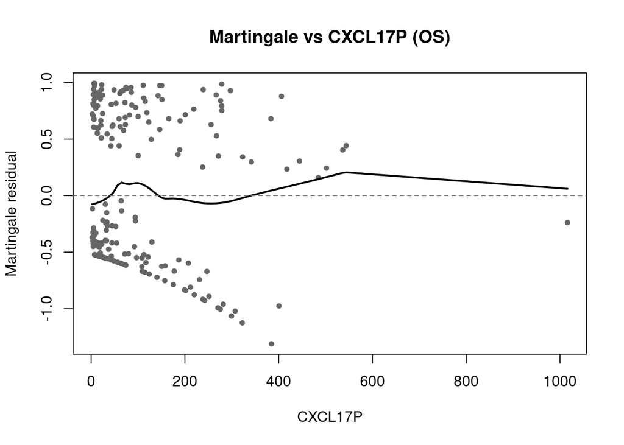

```r
mart_plot <- function(S, data, xvar, main_suffix=""){
  fit <- coxph(S ~ data[[xvar]], data=data, ties="efron", x=TRUE, y=TRUE)
  rM  <- resid(fit, type="martingale")
  xx  <- data[[xvar]]
  op <- par(mfrow=c(1,1))
  plot(xx, rM, pch=20, col="gray40",
       xlab=xvar, ylab="Martingale residual",
       main=paste("Martingale vs", xvar, main_suffix))
  lines(lowess(xx, rM, f=2/3), lwd=2)
  abline(h=0, lty=2, col="gray50")
  par(op)
  invisible(fit)
}

fit_os_best  <- mart_plot(S_OS,  hc, best_os,  "(OS)")
```

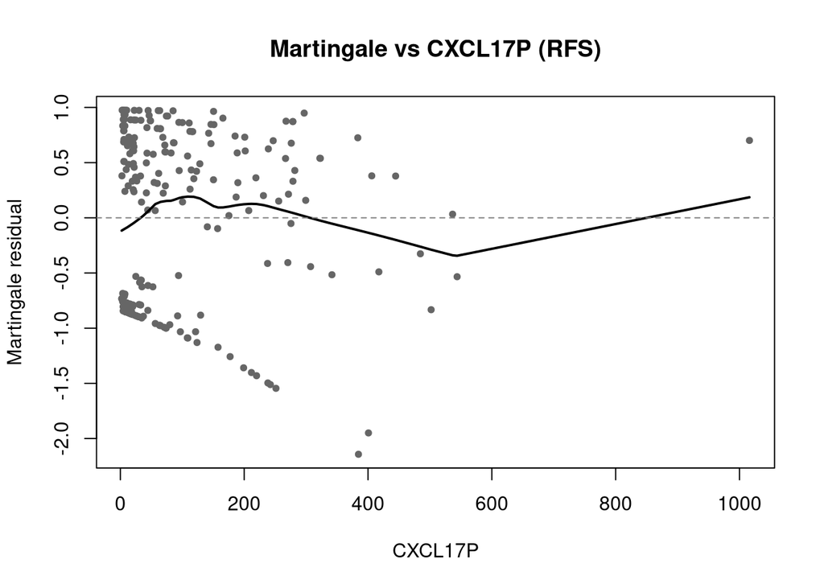

```r
fit_rfs_best <- mart_plot(S_RFS, hc, best_rfs, "(RFS)")
```

- loess 곡선이 수평에 가깝다고 보기 힘들어 보입니다.( + 이상점 후보가 보인다)

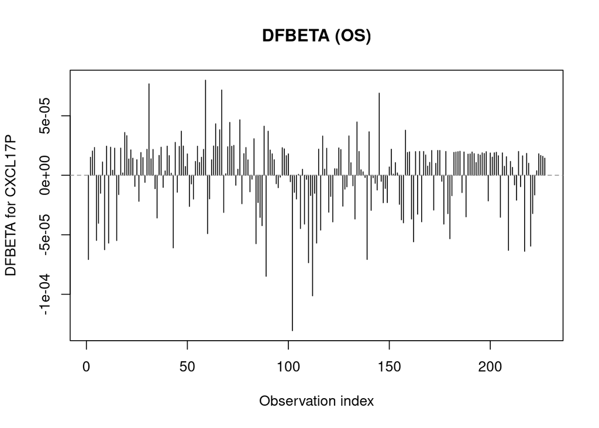

```r
#
resid.dfbeta  <- residuals(fit_os_best, type = "dfbeta")
resid.dfbeta <- cbind(resid.dfbeta)

resid.dfbetas <- residuals(fit_os_best, type = "dfbetas")
resid.dfbetas <- cbind(resid.dfbetas)

## 단일 예측자 모형이므로 1열이 CXCL17P
plot(resid.dfbeta[,1], type="h",
     xlab="Observation index", ylab="DFBETA for CXCL17P",
     main="DFBETA (OS)"); abline(h=0, lty=2, col="gray60")
```

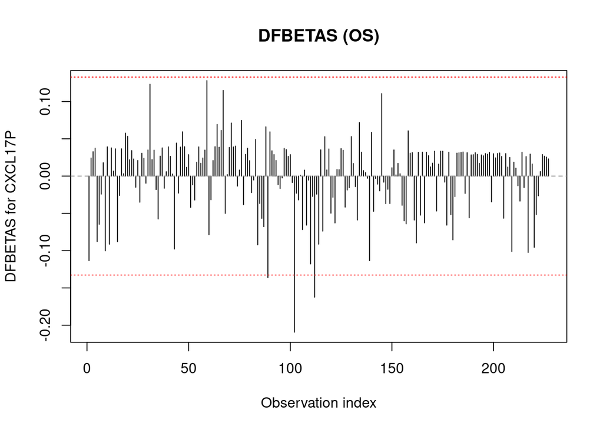

```r
plot(resid.dfbetas[,1], type="h",
     xlab="Observation index", ylab="DFBETAS for CXCL17P",
     main="DFBETAS (OS)"); abline(h=0, lty=2, col="gray60")

## |DFBETA| > 2/sqrt(n) 이면 강한 영향 후보
obsn = length(resid.dfbeta)
abline(h =  2/sqrt(obsn), lty=3, col="red")
abline(h = -2/sqrt(obsn), lty=3, col="red")
```

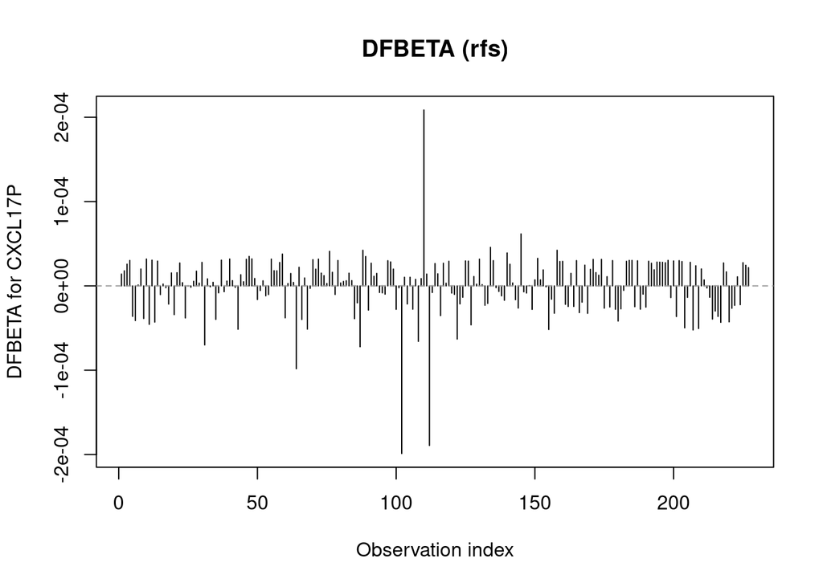

```r
#
resid.dfbeta  <- residuals(fit_rfs_best, type = "dfbeta")
resid.dfbeta <- cbind(resid.dfbeta)

resid.dfbetas <- residuals(fit_rfs_best, type = "dfbetas")
resid.dfbetas <- cbind(resid.dfbetas)

## 단일 예측자 모형이므로 1열이 CXCL17P
plot(resid.dfbeta[,1], type="h",
     xlab="Observation index", ylab="DFBETA for CXCL17P",
     main="DFBETA (rfs)"); abline(h=0, lty=2, col="gray60")
```

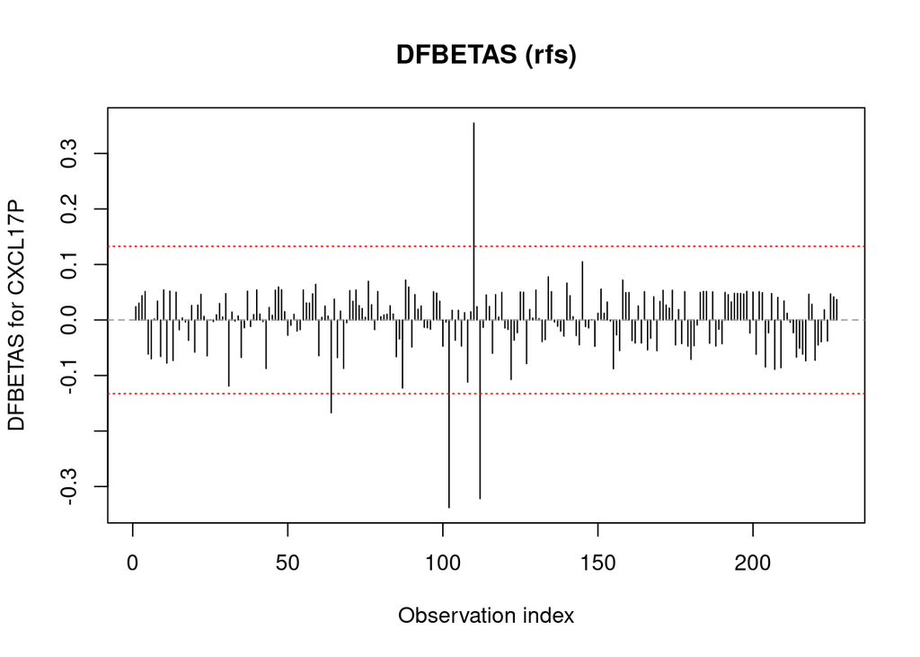

```r
plot(resid.dfbetas[,1], type="h",
     xlab="Observation index", ylab="DFBETAS for CXCL17P",
     main="DFBETAS (rfs)"); abline(h=0, lty=2, col="gray60")

## |DFBETA| > 2/sqrt(n) 이면 강한 영향 후보
obsn = length(resid.dfbeta)
abline(h =  2/sqrt(obsn), lty=3, col="red")
abline(h = -2/sqrt(obsn), lty=3, col="red")
```

- DFBETAS의 값이 빨간 점선을 넘어간 값들이 아웃라이어 후보입니다.

#### 1.3.2.3 (c) Schoenfeld Residual

```r
z_os <- cox.zph(fit_os_best)
print(z_os)
```

```
##              chisq df    p
## data[[xvar]] 0.258  1 0.61
## GLOBAL       0.258  1 0.61
```

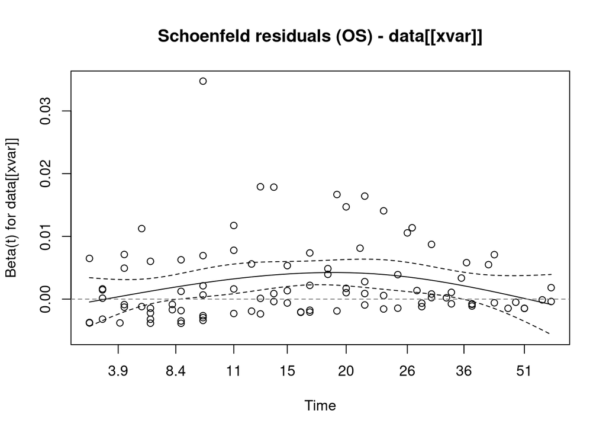

```r
term_names <- names(coef(fit_os_best))
vsel <- if (length(term_names) >= 1) term_names[1] else 1
plot(z_os, var = vsel, main = paste0("Schoenfeld residuals (OS) - ", vsel))
usr <- par("usr") # c(xmin, xmax, ymin, ymax)
segments(x0 = usr[1], y0 = 0, x1 = usr[2], y1 = 0, lty = 2, col = "gray50")
```

```r
z_rfs <- cox.zph(fit_rfs_best)
print(z_rfs)
```

```
##              chisq df     p
## data[[xvar]]  2.94  1 0.087
## GLOBAL        2.94  1 0.087
```

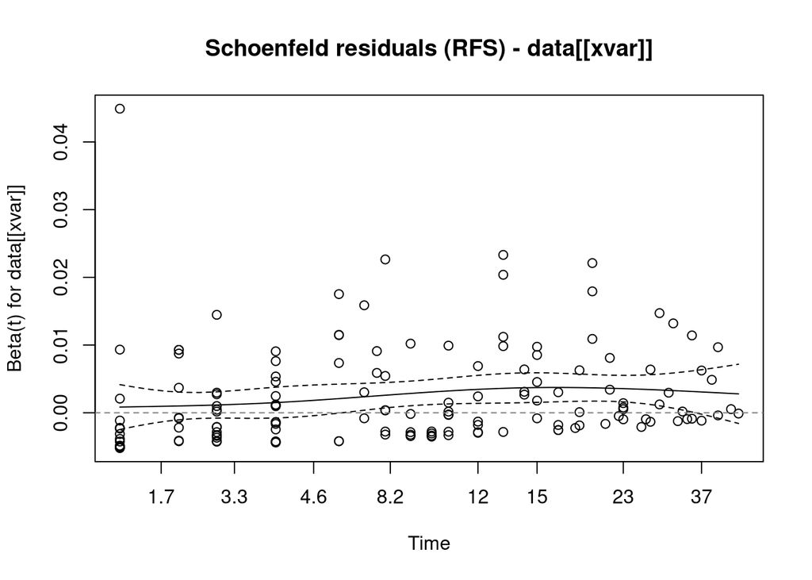

```r
term_names_r <- names(coef(fit_rfs_best))
vsel_r <- if (length(term_names_r) >= 1) term_names_r[1] else 1
plot(z_rfs, var = vsel_r, main = paste0("Schoenfeld residuals (RFS) - ", vsel_r))
usr <- par("usr")
segments(x0 = usr[1], y0 = 0, x1 = usr[2], y1 = 0, lty = 2, col = "gray50")
```

- OS: Schoenfeld 잔차 검정에서 p=0.61로 PH 가정 위반이 아니라고 할수 있습니다.
- RFS: Schoenfeld 잔차 검정에서 p=0.087로 PH 가정 위반이 아니라고 할수 있습니다.

[figure not shown]